# Long and wide data

```r
library(tidyverse)
```

# Pivoting functions

There are (at least) three pairs of pivoting functions that essentially do the same things: transform between wide and long data formats. The most commonly used tidyverse functions at the moment are gather() and spread(), which have (to some extent) replaced melt() and cast() - and are being replaced by pivot_longer() and pivot_wider(). We’ll have a look at each of these function pairs.

## What is long/wide data?

A “wide” data frame is one that has a variable spread over many columns (below, height is stored in column m for males and f for females). The column names provide information that could be stored in a column of its own.

| m | f |
| --- | --- |
| 171.7121 | 178.4883 |
| 186.6469 | 169.3353 |
| 171.9049 | 168.7066 |
| 180.4718 | 165.9330 |
| 175.7135 | 168.5505 |
| 180.4564 | 165.1781 |
| 188.1332 | 168.1035 |
| 187.5195 | 163.9988 |
| 176.0146 | 159.1490 |
| 164.2886 | 170.9392 |

### gather: wide-to-long

To make this data into long format, we want to **gather** the M and F columns. In a simple case like this, no additional arguments are needed.

| key | value |
| --- | --- |
| m | 171.7121 |
| m | 186.6469 |
| m | 171.9049 |
| m | 180.4718 |
| m | 175.7135 |
| m | 180.4564 |
| m | 188.1332 |
| m | 187.5195 |
| m | 176.0146 |
| m | 164.2886 |

[output cut: 10 more lines]

We can specify the desired column names if we’re not happy with the defaults.

| gender | height |
| --- | --- |
| m | 171.7121 |
| m | 186.6469 |
| m | 171.9049 |
| m | 180.4718 |
| m | 175.7135 |
| m | 180.4564 |
| m | 188.1332 |
| m | 187.5195 |
| m | 176.0146 |
| m | 164.2886 |

[output cut: 10 more lines]

Actually, this data frame is a special case because we’re gathering *all* existing columns and therefore don’t need to worry about extra columns. Usually, you should specify the columns that should be gathered.

| gender | height |
| --- | --- |
| m | 171.7121 |
| m | 186.6469 |
| m | 171.9049 |
| m | 180.4718 |
| m | 175.7135 |
| m | 180.4564 |
| m | 188.1332 |
| m | 187.5195 |
| m | 176.0146 |
| m | 164.2886 |

[output cut: 10 more lines]

#### Gathering specific columns

The tibble df represents repeated-measures data: it has one row per participant, and measured values from three sessions for each participant.

| participant | group | session1 | session2 | session3 |
| --- | --- | --- | --- | --- |
| 1 | Control | 4.247092 | 10.5353435 | 9.6759095 |
| 2 | Treatment | 5.867287 | 7.1695297 | 9.1285452 |
| 3 | Control | 3.828743 | 4.1362783 | 6.2982599 |
| 4 | Treatment | 8.690562 | -0.6440997 | -1.9574068 |
| 5 | Control | 6.159016 | 9.3747928 | 8.4793030 |
| 6 | Treatment | 3.859063 | 5.8651992 | 5.7754850 |
| 7 | Control | 6.474858 | 5.9514292 | 5.3768180 |
| 8 | Treatment | 6.976649 | 8.8315086 | 0.1169905 |
| 9 | Control | 6.651563 | 8.4636636 | 4.0873998 |
| 10 | Treatment | 4.889223 | 7.7817040 | 7.6717662 |

Let’s transform the data from wide to long format. Besides the participant and group variables, we want to have one column for the measurements taken over all sessions, and a new variable that indicates the session.

Like before, this is done with gather(). However, this time we have some variables that we *don’t* want to affect, namely participant and group. This needs to be taken care of in the gather function call.

| participant | group | session | value |
| --- | --- | --- | --- |
| 1 | Control | session1 | 4.2470924 |
| 2 | Treatment | session1 | 5.8672866 |
| 3 | Control | session1 | 3.8287428 |
| 4 | Treatment | session1 | 8.6905616 |
| 5 | Control | session1 | 6.1590155 |
| 6 | Treatment | session1 | 3.8590632 |
| 7 | Control | session1 | 6.4748581 |
| 8 | Treatment | session1 | 6.9766494 |
| 9 | Control | session1 | 6.6515627 |
| 10 | Treatment | session1 | 4.8892232 |

[output cut: 20 more lines]

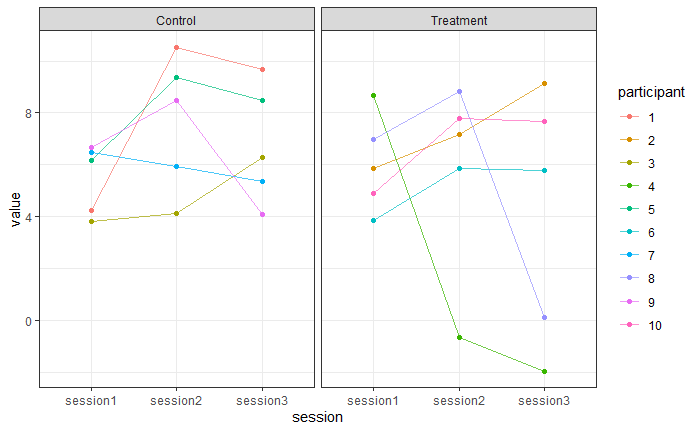

### spread: long-to-wide

**spread()** is the opposite of gather: it makes long data wider.

If we simply try to spread gender and height, we’ll get an error.

```r
heights_long %>%
  spread(gender, height)
```

```
Error: Each row of output must be identified by a unique combination of keys.
Keys are shared for 20 rows:
* 11, 12, 13, 14, 15, 16, 17, 18, 19, 20
* 1, 2, 3, 4, 5, 6, 7, 8, 9, 10

Run `rlang::last_error()` to see where the error occurred.
```

Let’s think for a moment what the spread() function tries to do. It needs to take the heights where gender = “m” and put them in one column; and heights where gender = “f” in another column. But how will it know how to match the rows? (Implicitly, we want to have the first “m” height on the same row as the first “f” height, but this isn’t specified anywhere!) We need to add unique identifiers (temporary row numbers) by group to avoid this confusion:

| f | m |
| --- | --- |
| 178.4883 | 171.7121 |
| 169.3353 | 186.6469 |
| 168.7066 | 171.9049 |
| 165.9330 | 180.4718 |
| 168.5505 | 175.7135 |
| 165.1781 | 180.4564 |
| 168.1035 | 188.1332 |
| 163.9988 | 187.5195 |
| 159.1490 | 176.0146 |
| 170.9392 | 164.2886 |

**So, whenever the spread function gives the error “Each row of output must be identified by a unique combination of keys”, you need to 1. group_by(X), 2. mutate row numbers and ungroup, 3. spread(X, value), and (optionally) 4. remove the row numbers.**

For comparison, it’s easy to make **df_long** wide since there is no ambiguity about rows (the participant variable already acts as a unique identifier).

| participant | group | session1 | session2 | session3 |
| --- | --- | --- | --- | --- |
| 1 | Control | 4.247092 | 10.5353435 | 9.6759095 |
| 2 | Treatment | 5.867287 | 7.1695297 | 9.1285452 |
| 3 | Control | 3.828743 | 4.1362783 | 6.2982599 |
| 4 | Treatment | 8.690562 | -0.6440997 | -1.9574068 |
| 5 | Control | 6.159016 | 9.3747928 | 8.4793030 |
| 6 | Treatment | 3.859063 | 5.8651992 | 5.7754850 |
| 7 | Control | 6.474858 | 5.9514292 | 5.3768180 |
| 8 | Treatment | 6.976649 | 8.8315086 | 0.1169905 |
| 9 | Control | 6.651563 | 8.4636636 | 4.0873998 |
| 10 | Treatment | 4.889223 | 7.7817040 | 7.6717662 |

## Some alternatives

### pivot_longer and pivot_wider

pivot_longer and pivot_wider are updated versions of gather and spread, respectively.

The key arguments of both functions are:

**pivot_longer**:  
names_to - name of the new variable that will be created from old variable names  
values_to - name of the new variable that will be created to contain the values  
**pivot_wider**:  
names_from - where to look for new variable names  
values_from - source of the values

Like gather(), pivot_longer() can be used without specifying new column names - it will use “name” and “value” by default.

| participant | group | session | value |
| --- | --- | --- | --- |
| 1 | Control | session1 | 4.2470924 |
| 1 | Control | session2 | 10.5353435 |
| 1 | Control | session3 | 9.6759095 |
| 2 | Treatment | session1 | 5.8672866 |
| 2 | Treatment | session2 | 7.1695297 |
| 2 | Treatment | session3 | 9.1285452 |
| 3 | Control | session1 | 3.8287428 |
| 3 | Control | session2 | 4.1362783 |
| 3 | Control | session3 | 6.2982599 |
| 4 | Treatment | session1 | 8.6905616 |

[output cut: 20 more lines]

There are additional arguments you can use inside pivot_longer. For example, if you want to get rid of the “session” in the beginning of each session number, the function can do it while pivoting. It can also transform the new session variable from character to integer.

| participant | group | session | value |
| --- | --- | --- | --- |
| 1 | Control | 1 | 4.2470924 |
| 1 | Control | 2 | 10.5353435 |
| 1 | Control | 3 | 9.6759095 |
| 2 | Treatment | 1 | 5.8672866 |
| 2 | Treatment | 2 | 7.1695297 |
| 2 | Treatment | 3 | 9.1285452 |
| 3 | Control | 1 | 3.8287428 |
| 3 | Control | 2 | 4.1362783 |
| 3 | Control | 3 | 6.2982599 |
| 4 | Treatment | 1 | 8.6905616 |

[output cut: 20 more lines]

Importantly, the pivot functions make it easier to work with datasets where multiple variables are combined in column names. It can separate the columns within the pivot_longer call (but with a bit more typing).

| gender | variable | value |
| --- | --- | --- |
| m | height | 186.15208 |
| f | height | 165.17738 |
| m | lifeExp | 84.76780 |
| f | lifeExp | 120.02427 |
| m | height | 177.38327 |
| f | height | 164.73319 |
| m | lifeExp | 67.59555 |
| f | lifeExp | 83.41140 |
| m | height | 180.32603 |
| f | height | 169.48482 |

[output cut: 30 more lines]

Similarly, we can create variable names from multiple variables when transforming to wide format.

| session | 1_Control | 2_Treatment | 3_Control | 4_Treatment | 5_Control | 6_Treatment | 7_Control | 8_Treatment | 9_Control | 10_Treatment |
| --- | --- | --- | --- | --- | --- | --- | --- | --- | --- | --- |
| session1 | 4.247092 | 5.867287 | 3.828743 | 8.6905616 | 6.159016 | 3.859063 | 6.474858 | 6.9766494 | 6.651563 | 4.889223 |
| session2 | 10.535344 | 7.169530 | 4.136278 | -0.6440997 | 9.374793 | 5.865199 | 5.951429 | 8.8315086 | 8.463664 | 7.781704 |
| session3 | 9.675909 | 9.128545 | 6.298260 | -1.9574068 | 8.479303 | 5.775485 | 5.376818 | 0.1169905 | 4.087400 | 7.671766 |

### reshape2 package: melt and cast

```r
library(reshape2)
```

There are also functions in the reshape2 package to transform between long and wide data formats:

- melt takes wide-format data and melts it into long-format data
- cast takes long-format data and casts it into wide-format data

They exist mainly for historical reasons (and have been updated to gather() and spread()), but can also be used with other data formats besides data frames.

(Note that the data.table library has its own melting and casting functions, too!)

The melt function does some guessing: it assumes that the columns with numerical values (here session1:session3) need to be gathered. In this case, it’s correct!

```r
df %>%
  melt()
```

| participant | group | variable | value |
| --- | --- | --- | --- |
| 1 | Control | session1 | 4.2470924 |
| 2 | Treatment | session1 | 5.8672866 |
| 3 | Control | session1 | 3.8287428 |
| 4 | Treatment | session1 | 8.6905616 |
| 5 | Control | session1 | 6.1590155 |
| 6 | Treatment | session1 | 3.8590632 |
| 7 | Control | session1 | 6.4748581 |
| 8 | Treatment | session1 | 6.9766494 |
| 9 | Control | session1 | 6.6515627 |
| 10 | Treatment | session1 | 4.8892232 |

[output cut: 20 more lines]

But the cast function needs to be given the “casting formula”, which looks quite different from anything we’ve seen in other reshaping functions:

| participant | group | session1 | session2 | session3 |
| --- | --- | --- | --- | --- |
| 1 | Control | 4.247092 | 10.5353435 | 9.6759095 |
| 2 | Treatment | 5.867287 | 7.1695297 | 9.1285452 |
| 3 | Control | 3.828743 | 4.1362783 | 6.2982599 |
| 4 | Treatment | 8.690562 | -0.6440997 | -1.9574068 |
| 5 | Control | 6.159016 | 9.3747928 | 8.4793030 |
| 6 | Treatment | 3.859063 | 5.8651992 | 5.7754850 |
| 7 | Control | 6.474858 | 5.9514292 | 5.3768180 |
| 8 | Treatment | 6.976649 | 8.8315086 | 0.1169905 |
| 9 | Control | 6.651563 | 8.4636636 | 4.0873998 |
| 10 | Treatment | 4.889223 | 7.7817040 | 7.6717662 |

## Data wrangling example: billboard data

The billboard dataset (from tidyr package) contains top 100 song rankings in the year 2000. It is in a wide format: there are separate columns for weeks 1-76. The week columns contain missing values for the weeks that the song wasn’t in the charts. In a format like this, you can easily see the number of unique tracks (317) based on the number of rows, since the tracks don’t need to be repeated. However, it’s less easy to work with the week/rank columns.

In this example, we will work the data into a longer format to calculate some key metrics for the tracks. Then, we will have a closer look at a subset of the data. These require reshaping the data a couple of times. Focus on how (and why) the reshaping is done, and think of how it could be done with pivot_wider and pivot_longer instead of spread and gather.

| artist | track | date.entered | wk1 | wk2 | wk3 | wk4 | wk5 | wk6 | wk7 | wk8 | wk9 | wk10 | wk11 | wk12 | wk13 | wk14 | wk15 | wk16 | wk17 | wk18 | wk19 | wk20 | wk21 | wk22 | wk23 | wk24 | wk25 | wk26 | wk27 | … |
| --- | --- | --- | --- | --- | --- | --- | --- | --- | --- | --- | --- | --- | --- | --- | --- | --- | --- | --- | --- | --- | --- | --- | --- | --- | --- | --- | --- | --- | --- | --- |
| 2 Pac | Baby Don't Cry (Keep... | 2000-02-26 | 87 | 82 | 72 | 77 | 87 | 94 | 99 | NA | NA | NA | NA | NA | NA | NA | NA | NA | NA | NA | NA | NA | NA | NA | NA | NA | NA | NA | NA | … |
| 2Ge+her | The Hardest Part Of ... | 2000-09-02 | 91 | 87 | 92 | NA | NA | NA | NA | NA | NA | NA | NA | NA | NA | NA | NA | NA | NA | NA | NA | NA | NA | NA | NA | NA | NA | NA | NA | … |
| 3 Doors Down | Kryptonite | 2000-04-08 | 81 | 70 | 68 | 67 | 66 | 57 | 54 | 53 | 51 | 51 | 51 | 51 | 47 | 44 | 38 | 28 | 22 | 18 | 18 | 14 | 12 | 7 | 6 | 6 | 6 | 5 | 5 | … |
| 3 Doors Down | Loser | 2000-10-21 | 76 | 76 | 72 | 69 | 67 | 65 | 55 | 59 | 62 | 61 | 61 | 59 | 61 | 66 | 72 | 76 | 75 | 67 | 73 | 70 | NA | NA | NA | NA | NA | NA | NA | … |
| 504 Boyz | Wobble Wobble | 2000-04-15 | 57 | 34 | 25 | 17 | 17 | 31 | 36 | 49 | 53 | 57 | 64 | 70 | 75 | 76 | 78 | 85 | 92 | 96 | NA | NA | NA | NA | NA | NA | NA | NA | NA | … |
| 98^0 | Give Me Just One Nig... | 2000-08-19 | 51 | 39 | 34 | 26 | 26 | 19 | 2 | 2 | 3 | 6 | 7 | 22 | 29 | 36 | 47 | 67 | 66 | 84 | 93 | 94 | NA | NA | NA | NA | NA | NA | NA | … |
| A*Teens | Dancing Queen | 2000-07-08 | 97 | 97 | 96 | 95 | 100 | NA | NA | NA | NA | NA | NA | NA | NA | NA | NA | NA | NA | NA | NA | NA | NA | NA | NA | NA | NA | NA | NA | … |
| Aaliyah | I Don't Wanna | 2000-01-29 | 84 | 62 | 51 | 41 | 38 | 35 | 35 | 38 | 38 | 36 | 37 | 37 | 38 | 49 | 61 | 63 | 62 | 67 | 83 | 86 | NA | NA | NA | NA | NA | NA | NA | … |
| Aaliyah | Try Again | 2000-03-18 | 59 | 53 | 38 | 28 | 21 | 18 | 16 | 14 | 12 | 10 | 9 | 8 | 6 | 1 | 2 | 2 | 2 | 2 | 3 | 4 | 5 | 5 | 6 | 9 | 13 | 14 | 16 | … |
| Adams, Yolanda | Open My Heart | 2000-08-26 | 76 | 76 | 74 | 69 | 68 | 67 | 61 | 58 | 57 | 59 | 66 | 68 | 61 | 67 | 59 | 63 | 67 | 71 | 79 | 89 | NA | NA | NA | NA | NA | NA | NA | … |

[output cut: 307 more lines]

Let’s gather the week columns to variables **week** and **rank**. Now, the artist, track and date.entered values will be repeated.

| artist | track | date.entered | week | rank |
| --- | --- | --- | --- | --- |
| 2 Pac | Baby Don't Cry (Keep... | 2000-02-26 | 1 | 87 |
| 2 Pac | Baby Don't Cry (Keep... | 2000-02-26 | 2 | 82 |
| 2 Pac | Baby Don't Cry (Keep... | 2000-02-26 | 3 | 72 |
| 2 Pac | Baby Don't Cry (Keep... | 2000-02-26 | 4 | 77 |
| 2 Pac | Baby Don't Cry (Keep... | 2000-02-26 | 5 | 87 |
| 2 Pac | Baby Don't Cry (Keep... | 2000-02-26 | 6 | 94 |
| 2 Pac | Baby Don't Cry (Keep... | 2000-02-26 | 7 | 99 |
| 2Ge+her | The Hardest Part Of ... | 2000-09-02 | 1 | 91 |
| 2Ge+her | The Hardest Part Of ... | 2000-09-02 | 2 | 87 |
| 2Ge+her | The Hardest Part Of ... | 2000-09-02 | 3 | 92 |

[output cut: 990 more lines]

Now we can calculate the number of weeks that each of the songs was in the charts, as well as the best ranking of each song, and number of weeks spent at #1.

```r
billboard_long %>%
  group_by(artist, track) %>%
  summarise(weeks_in_charts = max(week),
            weeks_in_charts_2 = n_distinct(week),
            best_rank = min(rank),
            weeks_number_one = sum(rank == 1)) %>%
  ungroup
```

| artist | track | weeks_in_charts | weeks_in_charts_2 | best_rank | weeks_number_one |
| --- | --- | --- | --- | --- | --- |
| 2 Pac | Baby Don't Cry (Keep... | 7 | 7 | 72 | 0 |
| 2Ge+her | The Hardest Part Of ... | 3 | 3 | 87 | 0 |
| 3 Doors Down | Kryptonite | 53 | 53 | 3 | 0 |
| 3 Doors Down | Loser | 20 | 20 | 55 | 0 |
| 504 Boyz | Wobble Wobble | 18 | 18 | 17 | 0 |
| 98^0 | Give Me Just One Nig... | 20 | 20 | 2 | 0 |
| A*Teens | Dancing Queen | 5 | 5 | 95 | 0 |
| Aaliyah | I Don't Wanna | 20 | 20 | 35 | 0 |
| Aaliyah | Try Again | 32 | 32 | 1 | 1 |
| Adams, Yolanda | Open My Heart | 20 | 20 | 57 | 0 |

[output cut: 307 more lines]

Let’s create a date variable: it’s calculated from date.entered and week, and it shows the actual date for each week.

| artist | track | date.entered | week | rank | date |
| --- | --- | --- | --- | --- | --- |
| 2 Pac | Baby Don't Cry (Keep... | 2000-02-26 | 1 | 87 | 2000-02-26 |
| 2 Pac | Baby Don't Cry (Keep... | 2000-02-26 | 2 | 82 | 2000-03-04 |
| 2 Pac | Baby Don't Cry (Keep... | 2000-02-26 | 3 | 72 | 2000-03-11 |
| 2 Pac | Baby Don't Cry (Keep... | 2000-02-26 | 4 | 77 | 2000-03-18 |
| 2 Pac | Baby Don't Cry (Keep... | 2000-02-26 | 5 | 87 | 2000-03-25 |
| 2 Pac | Baby Don't Cry (Keep... | 2000-02-26 | 6 | 94 | 2000-04-01 |
| 2 Pac | Baby Don't Cry (Keep... | 2000-02-26 | 7 | 99 | 2000-04-08 |
| 2Ge+her | The Hardest Part Of ... | 2000-09-02 | 1 | 91 | 2000-09-02 |
| 2Ge+her | The Hardest Part Of ... | 2000-09-02 | 2 | 87 | 2000-09-09 |
| 2Ge+her | The Hardest Part Of ... | 2000-09-02 | 3 | 92 | 2000-09-16 |

[output cut: 990 more lines]

The **date** variable can be separated into three columns, representing year, month and day. **Note**: there is an easy way to extract years/months/days from date objects using the lubridate package, but we’ll use the separate() function for demonstration purposes.

Now that we have year, month and day in separate columns, we can wrangle the data easily to see e.g. the development of the charts in the four weeks of June 2000.

| artist | track | day_3 | day_10 | day_17 | day_24 | date.entered | year | month |
| --- | --- | --- | --- | --- | --- | --- | --- | --- |
| Santana | Maria, Maria | 1 | 1 | 8 | 15 | 2000-02-12 | 2000 | 6 |
| Anthony, Marc | You Sang To Me | 2 | 2 | 5 | 7 | 2000-02-26 | 2000 | 6 |
| Hill, Faith | Breathe | 3 | 4 | 2 | 5 | 1999-11-06 | 2000 | 6 |
| Sisqo | Thong Song | 4 | 3 | 7 | 8 | 2000-01-29 | 2000 | 6 |
| Braxton, Toni | He Wasn't Man Enough | 5 | 11 | 12 | 16 | 2000-03-18 | 2000 | 6 |
| Iglesias, Enrique | Be With You | 6 | 5 | 4 | 1 | 2000-04-01 | 2000 | 6 |
| Vertical Horizon | Everything You Want | 7 | 8 | 3 | 3 | 2000-01-22 | 2000 | 6 |
| Aaliyah | Try Again | 8 | 6 | 1 | 2 | 2000-03-18 | 2000 | 6 |
| Gray, Macy | I Try | 9 | 10 | 11 | 14 | 2000-02-19 | 2000 | 6 |
| Joe | I Wanna Know | 10 | 12 | 10 | 6 | 2000-01-01 | 2000 | 6 |

[output cut: 107 more lines]

Then, we want to see how the rankings look over time - is there a general trend? We would like to plot **the number of weeks in charts** and **rankings** for each of the tracks. If we plot all of the data, it looks quite messy:

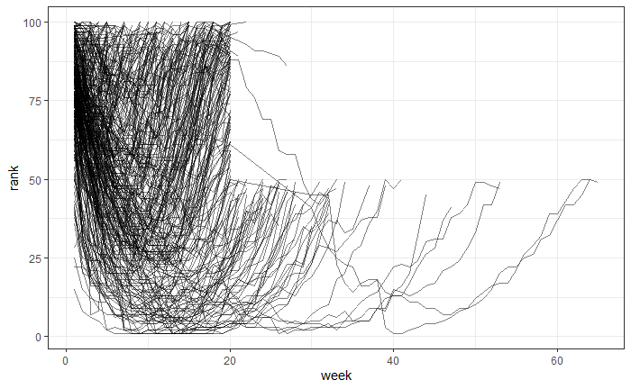

Let’s select a subset of the data: songs that were in top 20 in June 2000.

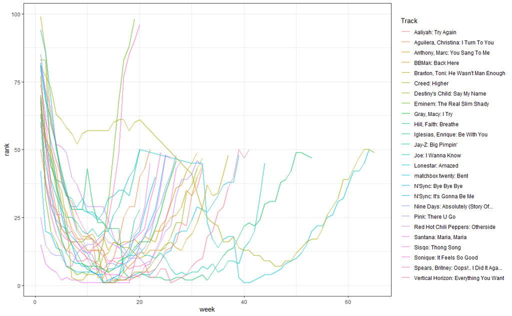